# “FitBit Data Analysis”

## “FitBit Data Analysis”

## Loading and preprocessing the data

After that the **activity.zip** file is extract in a new folder called **“repdata_data_activity”** in the working directory, load the data and see the structure.

```r
data <- read.csv("~/repdata_data_activity/activity.csv")
str(data)
```

```
## 'data.frame':    17568 obs. of  3 variables:
##  $ steps   : int  NA NA NA NA NA NA NA NA NA NA ...
##  $ date    : Factor w/ 61 levels "2012-10-01","2012-10-02",..: 1 1 1 1 1 1 1 1 1 1 ...
##  $ interval: int  0 5 10 15 20 25 30 35 40 45 ...
```

## What is mean total number of steps taken per day?

Calculate the mean of the total number of steps per day, see the structure of the new data, plot a histogram of it and calculate the mean and the median of steps taken per day.

```r
data1 <- aggregate(steps ~ date, data, sum)
str(data1)
```

```
## 'data.frame':    53 obs. of  2 variables:
##  $ date : Factor w/ 61 levels "2012-10-01","2012-10-02",..: 2 3 4 5 6 7 9 10 11 12 ...
##  $ steps: int  126 11352 12116 13294 15420 11015 12811 9900 10304 17382 ...
```

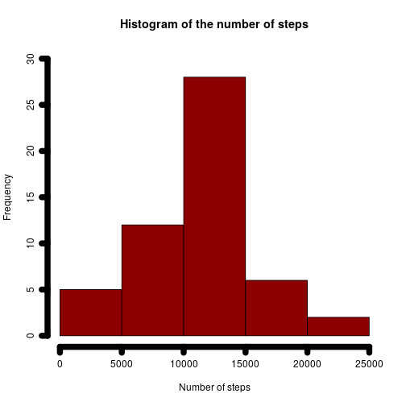

```r
hist(data1$steps, lwd = 10, col = "dark red", ylim = c(0,30), xlab = "Number of steps", main = "Histogram of the number of steps")
```

```r
data1mean <- mean(data1$steps)
data1median <- median(data1$steps)
```

The mean is 1.0766189 × 10<sup>4</sup>. The median is 10765.

## What is the average daily activity pattern?

Calculate the average daily activity pattern and plot a time series of it. Calculate the 5-minute interval, on average across all the days in the dataset, that contains the maximum number of steps.

```r
data2 <- aggregate(steps ~ interval, data, mean)
str(data2)
```

```
## 'data.frame':    288 obs. of  2 variables:
##  $ interval: int  0 5 10 15 20 25 30 35 40 45 ...
##  $ steps   : num  1.717 0.3396 0.1321 0.1509 0.0755 ...
```

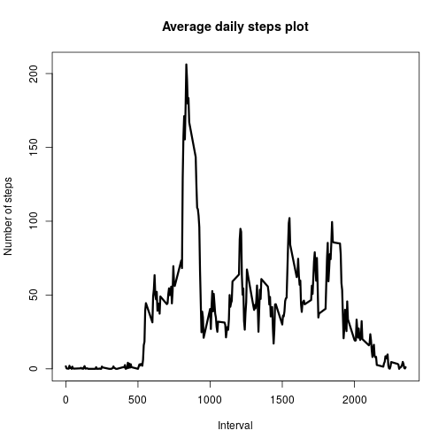

```r
plot(data2$interval, data2$steps, type = "l", xlab = "Interval", ylab = "Number of steps",
     main = "Average daily steps plot", lwd = 3)
```

```r
maxint <- data2[which.max(data2$steps), 1]
```

The interval is: 835.

## Imputing missing values

Calculate and report the total number of missing values in the dataset. Create a new dataset that is equal to the original dataset but with the missing data filled in. This is made using the 5min interval mean to replace the missing values. Make a histogram of the total number of steps taken each day and a histogram of the new total number of steps taken each day with fixed missing values. Calculate and report the mean and median total number of steps taken per day.

```r
mv <- sum(is.na(data$steps))
```

The missing values are: 2304.

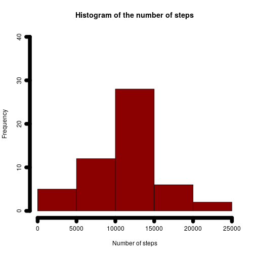

```r
data2 <- data
nas <- is.na(data2$steps)
avg5minint<- tapply(data2$steps, data2$interval, mean, na.rm=TRUE)
data2$steps[nas] <- avg5minint[as.character(data2$interval[nas])]

totstep1 <- aggregate(steps ~ date, data, sum)
totstep2 <- aggregate(steps ~ date, data2, sum)


hist(totstep1$steps, lwd = 10, col = "dark red", ylim = c(0,40), xlab = "Number of steps", main = "Histogram of the number of steps")
```

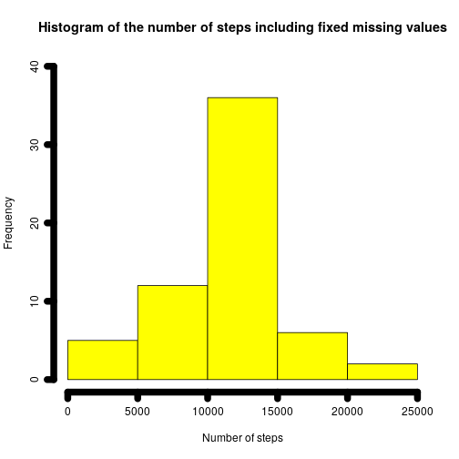

```r
hist(totstep2$steps, lwd = 10, col = "yellow", ylim = c(0,40), xlab = "Number of steps", main = "Histogram of the number of steps including fixed missing values")
```

```r
data2mean <- mean(totstep2$steps)
data2median <- median(totstep2$steps)
```

The fixed mean is:1.0766189 × 10<sup>4</sup>. The fixed median is:1.0766189 × 10<sup>4</sup>.

## Are there differences in activity patterns between weekdays and weekends?

Create a new factor variable in the dataset with two levels – “weekday” and “weekend” indicating whether a given date is a weekday or weekend day. Make a panel plot containing a time series plot.

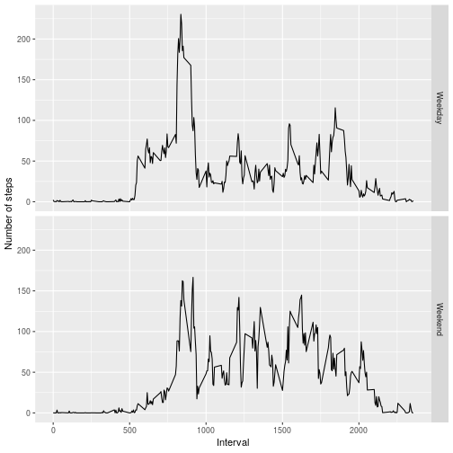

```r
library(ggplot2)

wd <- c("lunedì", "martedì", "mercoledì", "giovedì", "venerdì")
data2$dow = as.factor(ifelse(is.element(weekdays(as.Date(data2$date)), wd), "Weekday", "Weekend"))
totstepdow <- aggregate(steps ~ interval + dow, data2, mean)

ggplot(totstepdow, aes(interval, steps)) +
    geom_line() +
    facet_grid(dow ~ .) +
    xlab("Interval") +
    ylab("Number of steps")
```